# R recap

Mark Dunning; mark ‘dot’ dunning ‘at’ cruk.cam.ac.uk, Oscar Rueda; oscar ‘dot’ rueda ‘at’ cruk.cam.ac.uk

Last modified: 11 Feb 2016

In this session we will review some of the basic features of the R language, before proceeding more-complicated workflows required for the analysis of microarray, and other high-throughput data.

We recommend using the RStudio GUI for this course.

## Getting help with R

R has an in-built help system. At the *console*, you can type `?` followed by the name of a function. This will bring-up the documentation for the function; which includes the expected inputs (*arguments*), the output you should expect from the function and some use-cases.

```r
?mean
```

More-detailed information on particular packages is also available (see below)

## R packages

The **Packages** tab in the bottom-right panel of RStudio lists all packages that you currently have installed. Clicking on a package name will show a list of functions that available once that package has been loaded. The `library` function is used to load a package and make it’s functions / data available in your current R session. *You need to do this every time you load a new RStudio session*.

```r
library(beadarray)
```

There are functions for installing packages within R. If your package is part of the main **CRAN** repository, you can use `install.packages`

We will be using the `wakefield` R package in this practical. To install it, we do.

```r
install.packages("wakefield")
```

*Bioconductor* packages have their own install script, which you can download from the Bioconductor website

```r
source("http://www.bioconductor.org/biocLite.R")
biocLite("affy")
```

A package may have several *dependancies*; other R packages from which it uses functions or data types (re-using code from other packages is strongly-encouraged). If this is the case, the other R packages will be located and installed too.

So long as you stick with the same version of R, you won’t need to repeat this install process.

## Getting started

We are going to explore some of the basic features of R using some patient data; the kind of data that we might encounter in the wild. However, rather than using real-life data we are going to make some up. There is a package called `wakefield` that is particularly convenient for this task.

```r
library(wakefield)
```

Various patient characteristics can be generated. The following is a function that uses the package to create a *data frame* with various clinical characteristics. The number of patients we want to simulate is an argument.

```r
random_patients <- function(n) {
  as.data.frame(r_data_frame(
    n,
    id,
    name,
    race,
    sex,
    smokes,
    height,
    birth(random = TRUE, x = NULL, start = Sys.Date() - 365 * 45, k = 365*2,by = "1 days"),
    state,
    pet,
    grade_level(x=1:3),
    died,
    normal(name="Count"),
    date_stamp)
  )
}
```

We can now use the `random_patients` function to generate a data frame of fictitious patients

```r
patients <- random_patients(10)
```

In Rstudio , you can view the contents of this data frame in a tab.

```r
View(patients)
```

## Q. What are the dimensions of the data frame?

## Q. What columns are available?

*** HINT: see the `dim`, `ncol`, `nrow` and `colnames` functions

```
## [1] 10 13
```

```
##  [1] "ID"          "Name"        "Race"        "Sex"         "Smokes"
##  [6] "Height"      "Birth"       "State"       "Pet"         "Grade_Level"
## [11] "Died"        "Count"       "Date"
```

## Q. Can you think of two ways to access the Names of the patients?

## Q. What type of object is returned?

```
##  [1] "Sammie"  "Louie"   "Julian"  "Laverne" "Carey"   "Vernon"  "Tony"
##  [8] "Mike"    "Jeffrey" "Jordan"
```

```
##  [1] "Sammie"  "Louie"   "Julian"  "Laverne" "Carey"   "Vernon"  "Tony"
##  [8] "Mike"    "Jeffrey" "Jordan"
```

We can access the columns of a data frame by either

- knowing the column index
- knowing the column name

By column name is recommended, unless you can guarentee the columns will also be in the same order

*TOP TIP:* Use auto-complete with the key to get the name of the column correct

A vector (1-dimensional) is returned, the length of which is the same as the number of rows in the data frame. The vector could be stored as a variable and itself be subset or used in further calculations

```r
peeps <- patients$Name
peeps
```

```
##  [1] "Sammie"  "Louie"   "Julian"  "Laverne" "Carey"   "Vernon"  "Tony"
##  [8] "Mike"    "Jeffrey" "Jordan"
```

```r
length(peeps)
```

```
## [1] 10
```

```r
nchar(peeps)
```

```
##  [1] 6 5 6 7 5 6 4 4 7 6
```

```r
substr(peeps,1,3)
```

```
##  [1] "Sam" "Lou" "Jul" "Lav" "Car" "Ver" "Ton" "Mik" "Jef" "Jor"
```

The `summary` function is a useful way of summarising the data containing in each column. It will give information about the *type* of data (remember, data frames can have a mixture of numeric and character columns) and also an appropriate summary. For numeric columns, it will report some stats about the distribution of the data. For categorical data, it will report the different *levels*.

```r
summary(patients)
```

```
##       ID                Name                  Race       Sex
##  Length:10          Length:10          White    :6   Male  :8
##  Class :character   Class :character   Black    :3   Female:2
##  Mode  :character   Mode  :character   Hispanic :1
##                                        Asian    :0
##                                        Bi-Racial:0
##                                        Native   :0
##                                        (Other)  :0
##    Smokes            Height         Birth                       State
##  Mode :logical   Min.   :58.0   Min.   :1971-09-01   California    :3
##  FALSE:9         1st Qu.:65.0   1st Qu.:1972-02-28   Illinois      :2
##  TRUE :1         Median :67.5   Median :1972-07-13   Kentucky      :1
##  NA's :0         Mean   :67.4   Mean   :1972-07-10   Oregon        :1
##                  3rd Qu.:70.0   3rd Qu.:1972-12-30   Pennsylvania  :1
##                  Max.   :79.0   Max.   :1973-02-13   South Carolina:1
##                                                      (Other)       :1
##     Pet    Grade_Level    Died             Count
##  Dog  :2   1:5         Mode :logical   Min.   :-1.6629
##  Cat  :2   2:2         FALSE:3         1st Qu.:-0.7728
##  None :5   3:3         TRUE :7         Median : 0.0185
##  Bird :1               NA's :0         Mean   :-0.2662
##  Horse:0                               3rd Qu.: 0.3454
##                                        Max.   : 0.5301
##
##       Date
##  Min.   :2015-05-11
##  1st Qu.:2015-07-18
##  Median :2015-09-26
##  Mean   :2015-09-19
##  3rd Qu.:2015-11-11
##  Max.   :2016-02-11
##
```

## Q. Can you identify

### which columns contain numerical data?

### which columns contain categorical data?

### which columns contain logical (`TRUE` or `FALSE`) values?

## Subsetting

A data frame can be subset using square brackes`[]` placed after the name of the data frame. As a data frame is a two-dimensional object, you need a *row* and *column* index, or vector indices.

## Q. Make sure you can understand the behaviour of the following commands

```r
patients[1,2]
patients[2,1]
patients[c(1,2,3),1]
patients[c(1,2,3),c(1,2,3)]
```

*Note that the data frame is not altered* we are just seeing what a subset of the data looks like and not changing the underlying data. If we wanted to do this, we would need to create a new variale.

```r
patients
```

```
##    ID    Name     Race    Sex Smokes Height      Birth          State  Pet
## 1  01  Sammie    Black   Male  FALSE     69 1972-07-24         Oregon  Dog
## 2  02   Louie    Black Female   TRUE     70 1973-02-01       Kentucky  Cat
## 3  03  Julian    White   Male  FALSE     79 1972-05-18     California None
## 4  04 Laverne    White Female  FALSE     65 1973-01-19       Illinois None
## 5  05   Carey    White   Male  FALSE     62 1971-09-01          Texas  Dog
## 6  06  Vernon    White   Male  FALSE     58 1973-02-13     California Bird
## 7  07    Tony Hispanic   Male  FALSE     70 1971-12-18   Pennsylvania None
## 8  08    Mike    White   Male  FALSE     70 1972-07-03     California None
## 9  09 Jeffrey    Black   Male  FALSE     65 1972-02-02 South Carolina None
## 10 10  Jordan    White   Male  FALSE     66 1972-11-01       Illinois  Cat
##    Grade_Level  Died      Count       Date
## 1            1  TRUE  0.2053383 2015-05-11
## 2            3 FALSE -1.6629067 2015-05-11
## 3            1  TRUE  0.1881856 2015-07-11
## 4            1 FALSE  0.3920914 2015-08-11
## 5            2  TRUE  0.5301359 2015-09-11
## 6            2  TRUE -0.1511945 2015-10-11
## 7            1 FALSE -0.4379571 2015-11-11
## 8            3  TRUE -1.2441501 2015-11-11
## 9            3  TRUE  0.4025113 2016-01-11
## 10           1  TRUE -0.8844429 2016-02-11
```

Should we wish to see all rows, or all columns, we can neglect either the row or column index

## Q. Make sure you can understand the behaviour of the following commands

```r
patients[1,]
```

```
##   ID   Name  Race  Sex Smokes Height      Birth  State Pet Grade_Level
## 1 01 Sammie Black Male  FALSE     69 1972-07-24 Oregon Dog           1
##   Died     Count       Date
## 1 TRUE 0.2053383 2015-05-11
```

```r
patients[,1]
```

```
##  [1] "01" "02" "03" "04" "05" "06" "07" "08" "09" "10"
```

```r
patients[,c(1,2)]
```

```
##    ID    Name
## 1  01  Sammie
## 2  02   Louie
## 3  03  Julian
## 4  04 Laverne
## 5  05   Carey
## 6  06  Vernon
## 7  07    Tony
## 8  08    Mike
## 9  09 Jeffrey
## 10 10  Jordan
```

## Q. How can we view all information about the first six patients?

*** HINT `head` is commonly-used to give a snapshot of a data frame. Otherwise, you can use the `[row,column]` notation.

```
##   ID    Name  Race    Sex Smokes Height      Birth      State  Pet
## 1 01  Sammie Black   Male  FALSE     69 1972-07-24     Oregon  Dog
## 2 02   Louie Black Female   TRUE     70 1973-02-01   Kentucky  Cat
## 3 03  Julian White   Male  FALSE     79 1972-05-18 California None
## 4 04 Laverne White Female  FALSE     65 1973-01-19   Illinois None
## 5 05   Carey White   Male  FALSE     62 1971-09-01      Texas  Dog
## 6 06  Vernon White   Male  FALSE     58 1973-02-13 California Bird
##   Grade_Level  Died      Count       Date
## 1           1  TRUE  0.2053383 2015-05-11
## 2           3 FALSE -1.6629067 2015-05-11
## 3           1  TRUE  0.1881856 2015-07-11
## 4           1 FALSE  0.3920914 2015-08-11
## 5           2  TRUE  0.5301359 2015-09-11
## 6           2  TRUE -0.1511945 2015-10-11
```

Rather than selecting rows based on their *numeric* index (as in the previous example) we can use what we call a *logical test*. This is a test that gives either a `TRUE` or `FALSE` result. When applied to subsetting, only rows with a `TRUE` result get returned.

For example we could compare the `Count` variable to zero. The result is a *vector* of `TRUE` or `FALSE`; one for each row in the data frame

```r
patients$Count < 0
```

```
##  [1] FALSE  TRUE FALSE FALSE FALSE  TRUE  TRUE  TRUE FALSE  TRUE
```

This R code can be put inside the square brackets.

```r
patients[patients$Count<0, ]
```

```
##    ID   Name     Race    Sex Smokes Height      Birth        State  Pet
## 2  02  Louie    Black Female   TRUE     70 1973-02-01     Kentucky  Cat
## 6  06 Vernon    White   Male  FALSE     58 1973-02-13   California Bird
## 7  07   Tony Hispanic   Male  FALSE     70 1971-12-18 Pennsylvania None
## 8  08   Mike    White   Male  FALSE     70 1972-07-03   California None
## 10 10 Jordan    White   Male  FALSE     66 1972-11-01     Illinois  Cat
##    Grade_Level  Died      Count       Date
## 2            3 FALSE -1.6629067 2015-05-11
## 6            2  TRUE -0.1511945 2015-10-11
## 7            1 FALSE -0.4379571 2015-11-11
## 8            3  TRUE -1.2441501 2015-11-11
## 10           1  TRUE -0.8844429 2016-02-11
```

If we wanted to know about the patients that had died, we could do;

```r
deceased <- patients[patients$Died == TRUE,]
deceased
```

```
##    ID    Name  Race  Sex Smokes Height      Birth          State  Pet
## 1  01  Sammie Black Male  FALSE     69 1972-07-24         Oregon  Dog
## 3  03  Julian White Male  FALSE     79 1972-05-18     California None
## 5  05   Carey White Male  FALSE     62 1971-09-01          Texas  Dog
## 6  06  Vernon White Male  FALSE     58 1973-02-13     California Bird
## 8  08    Mike White Male  FALSE     70 1972-07-03     California None
## 9  09 Jeffrey Black Male  FALSE     65 1972-02-02 South Carolina None
## 10 10  Jordan White Male  FALSE     66 1972-11-01       Illinois  Cat
##    Grade_Level Died      Count       Date
## 1            1 TRUE  0.2053383 2015-05-11
## 3            1 TRUE  0.1881856 2015-07-11
## 5            2 TRUE  0.5301359 2015-09-11
## 6            2 TRUE -0.1511945 2015-10-11
## 8            3 TRUE -1.2441501 2015-11-11
## 9            3 TRUE  0.4025113 2016-01-11
## 10           1 TRUE -0.8844429 2016-02-11
```

In fact, this is equivalent

```r
deceased <- patients[patients$Died,]
```

The test of equality `==` also works for text

```r
patients[patients$Race == "White",]
```

```
##    ID    Name  Race    Sex Smokes Height      Birth      State  Pet
## 3  03  Julian White   Male  FALSE     79 1972-05-18 California None
## 4  04 Laverne White Female  FALSE     65 1973-01-19   Illinois None
## 5  05   Carey White   Male  FALSE     62 1971-09-01      Texas  Dog
## 6  06  Vernon White   Male  FALSE     58 1973-02-13 California Bird
## 8  08    Mike White   Male  FALSE     70 1972-07-03 California None
## 10 10  Jordan White   Male  FALSE     66 1972-11-01   Illinois  Cat
##    Grade_Level  Died      Count       Date
## 3            1  TRUE  0.1881856 2015-07-11
## 4            1 FALSE  0.3920914 2015-08-11
## 5            2  TRUE  0.5301359 2015-09-11
## 6            2  TRUE -0.1511945 2015-10-11
## 8            3  TRUE -1.2441501 2015-11-11
## 10           1  TRUE -0.8844429 2016-02-11
```

## Q. Can you create a data frame of dog owners?

```
##   ID   Name  Race  Sex Smokes Height      Birth  State Pet Grade_Level
## 1 01 Sammie Black Male  FALSE     69 1972-07-24 Oregon Dog           1
## 5 05  Carey White Male  FALSE     62 1971-09-01  Texas Dog           2
##   Died     Count       Date
## 1 TRUE 0.2053383 2015-05-11
## 5 TRUE 0.5301359 2015-09-11
```

There are a couple of ways of testing for more than one text value. The first uses an *or* `|` statement. i.e. testing if the value of `Pet` is `Dog` *or* the value is `Cat`.

The `%in%` function is a convenient function for testing which items in a vector correspond to a defined set of values.

```r
patients[patients$Pet == "Dog" | patients$Pet == "Cat",]
```

```
##    ID   Name  Race    Sex Smokes Height      Birth    State Pet
## 1  01 Sammie Black   Male  FALSE     69 1972-07-24   Oregon Dog
## 2  02  Louie Black Female   TRUE     70 1973-02-01 Kentucky Cat
## 5  05  Carey White   Male  FALSE     62 1971-09-01    Texas Dog
## 10 10 Jordan White   Male  FALSE     66 1972-11-01 Illinois Cat
##    Grade_Level  Died      Count       Date
## 1            1  TRUE  0.2053383 2015-05-11
## 2            3 FALSE -1.6629067 2015-05-11
## 5            2  TRUE  0.5301359 2015-09-11
## 10           1  TRUE -0.8844429 2016-02-11
```

```r
patients[patients$Pet %in% c("Dog","Cat"),]
```

```
##    ID   Name  Race    Sex Smokes Height      Birth    State Pet
## 1  01 Sammie Black   Male  FALSE     69 1972-07-24   Oregon Dog
## 2  02  Louie Black Female   TRUE     70 1973-02-01 Kentucky Cat
## 5  05  Carey White   Male  FALSE     62 1971-09-01    Texas Dog
## 10 10 Jordan White   Male  FALSE     66 1972-11-01 Illinois Cat
##    Grade_Level  Died      Count       Date
## 1            1  TRUE  0.2053383 2015-05-11
## 2            3 FALSE -1.6629067 2015-05-11
## 5            2  TRUE  0.5301359 2015-09-11
## 10           1  TRUE -0.8844429 2016-02-11
```

Similar to *or*, we can require that both tests are `TRUE` by using an *and* `&` operation. e.g. to look for white males.

```r
patients[patients$Race == "White" & patients$Sex =="Male",]
```

```
##    ID   Name  Race  Sex Smokes Height      Birth      State  Pet
## 3  03 Julian White Male  FALSE     79 1972-05-18 California None
## 5  05  Carey White Male  FALSE     62 1971-09-01      Texas  Dog
## 6  06 Vernon White Male  FALSE     58 1973-02-13 California Bird
## 8  08   Mike White Male  FALSE     70 1972-07-03 California None
## 10 10 Jordan White Male  FALSE     66 1972-11-01   Illinois  Cat
##    Grade_Level Died      Count       Date
## 3            1 TRUE  0.1881856 2015-07-11
## 5            2 TRUE  0.5301359 2015-09-11
## 6            2 TRUE -0.1511945 2015-10-11
## 8            3 TRUE -1.2441501 2015-11-11
## 10           1 TRUE -0.8844429 2016-02-11
```

## Q. Can you create a data frame of deceased patients with a ‘count’ < 0

```
##    ID   Name  Race  Sex Smokes Height      Birth      State  Pet
## 6  06 Vernon White Male  FALSE     58 1973-02-13 California Bird
## 8  08   Mike White Male  FALSE     70 1972-07-03 California None
## 10 10 Jordan White Male  FALSE     66 1972-11-01   Illinois  Cat
##    Grade_Level Died      Count       Date
## 6            2 TRUE -0.1511945 2015-10-11
## 8            3 TRUE -1.2441501 2015-11-11
## 10           1 TRUE -0.8844429 2016-02-11
```

## Ordering and sorting

A vector can be returned in sorted form using the `sort` function.

```r
sort(peeps)
```

```
##  [1] "Carey"   "Jeffrey" "Jordan"  "Julian"  "Laverne" "Louie"   "Mike"
##  [8] "Sammie"  "Tony"    "Vernon"
```

```r
sort(patients$Count,decreasing = TRUE)
```

```
##  [1]  0.5301359  0.4025113  0.3920914  0.2053383  0.1881856 -0.1511945
##  [7] -0.4379571 -0.8844429 -1.2441501 -1.6629067
```

However, if we want to sort an entire data frame a different approach is needed. The trick is to use `order`. Rather than giving a sorted set of *values*, it will give sorted *indices*.

```r
patients[order(patients$Count),]
```

```
##    ID    Name     Race    Sex Smokes Height      Birth          State  Pet
## 2  02   Louie    Black Female   TRUE     70 1973-02-01       Kentucky  Cat
## 8  08    Mike    White   Male  FALSE     70 1972-07-03     California None
## 10 10  Jordan    White   Male  FALSE     66 1972-11-01       Illinois  Cat
## 7  07    Tony Hispanic   Male  FALSE     70 1971-12-18   Pennsylvania None
## 6  06  Vernon    White   Male  FALSE     58 1973-02-13     California Bird
## 3  03  Julian    White   Male  FALSE     79 1972-05-18     California None
## 1  01  Sammie    Black   Male  FALSE     69 1972-07-24         Oregon  Dog
## 4  04 Laverne    White Female  FALSE     65 1973-01-19       Illinois None
## 9  09 Jeffrey    Black   Male  FALSE     65 1972-02-02 South Carolina None
## 5  05   Carey    White   Male  FALSE     62 1971-09-01          Texas  Dog
##    Grade_Level  Died      Count       Date
## 2            3 FALSE -1.6629067 2015-05-11
## 8            3  TRUE -1.2441501 2015-11-11
## 10           1  TRUE -0.8844429 2016-02-11
## 7            1 FALSE -0.4379571 2015-11-11
## 6            2  TRUE -0.1511945 2015-10-11
## 3            1  TRUE  0.1881856 2015-07-11
## 1            1  TRUE  0.2053383 2015-05-11
## 4            1 FALSE  0.3920914 2015-08-11
## 9            3  TRUE  0.4025113 2016-01-11
## 5            2  TRUE  0.5301359 2015-09-11
```

```r
patients[order(patients$Sex),]
```

```
##    ID    Name     Race    Sex Smokes Height      Birth          State  Pet
## 1  01  Sammie    Black   Male  FALSE     69 1972-07-24         Oregon  Dog
## 3  03  Julian    White   Male  FALSE     79 1972-05-18     California None
## 5  05   Carey    White   Male  FALSE     62 1971-09-01          Texas  Dog
## 6  06  Vernon    White   Male  FALSE     58 1973-02-13     California Bird
## 7  07    Tony Hispanic   Male  FALSE     70 1971-12-18   Pennsylvania None
## 8  08    Mike    White   Male  FALSE     70 1972-07-03     California None
## 9  09 Jeffrey    Black   Male  FALSE     65 1972-02-02 South Carolina None
## 10 10  Jordan    White   Male  FALSE     66 1972-11-01       Illinois  Cat
## 2  02   Louie    Black Female   TRUE     70 1973-02-01       Kentucky  Cat
## 4  04 Laverne    White Female  FALSE     65 1973-01-19       Illinois None
##    Grade_Level  Died      Count       Date
## 1            1  TRUE  0.2053383 2015-05-11
## 3            1  TRUE  0.1881856 2015-07-11
## 5            2  TRUE  0.5301359 2015-09-11
## 6            2  TRUE -0.1511945 2015-10-11
## 7            1 FALSE -0.4379571 2015-11-11
## 8            3  TRUE -1.2441501 2015-11-11
## 9            3  TRUE  0.4025113 2016-01-11
## 10           1  TRUE -0.8844429 2016-02-11
## 2            3 FALSE -1.6629067 2015-05-11
## 4            1 FALSE  0.3920914 2015-08-11
```

A final point on data frames is that we can export them out of R once we have done our data processing.

```r
countOrder <- patients[order(patients$Count),]
write.csv(countOrder, file="patientsOrderedByCount.csv")
```

## Simple plotting

Various simple plots are supported in the *base* distribution of R (what you get automatically when you download R). In the course, we will show how some of these plots can be used to inform us about the quality of microarray data, and to visualise our results.

Plotting is discussed in greater length on our [introductory R course](http://cambiotraining.github.io/r-intro/) and a useful reference is the [Quick-R](http://www.statmethods.net/graphs/index.html) page.

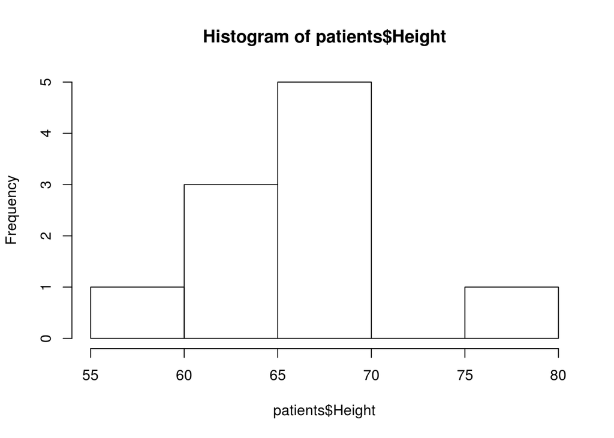

```r
hist(patients$Height)
```

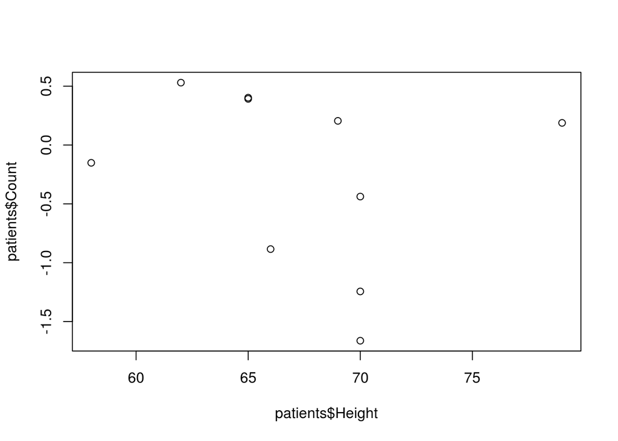

```r
plot(patients$Height,patients$Count)
```

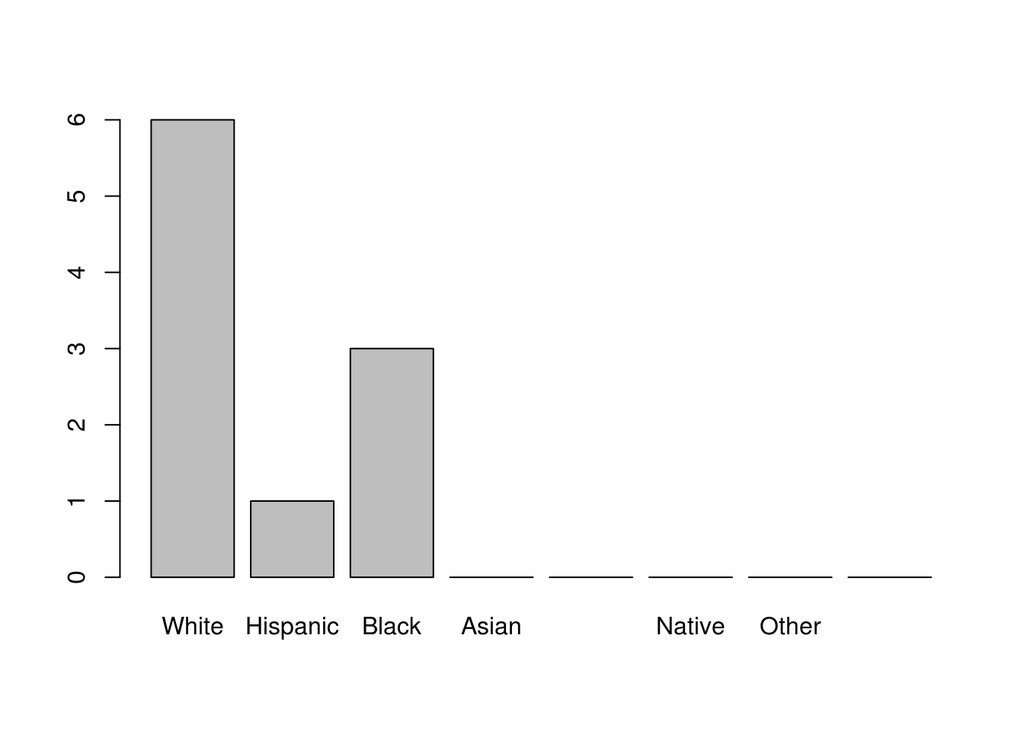

```r
barplot(table(patients$Race))
```

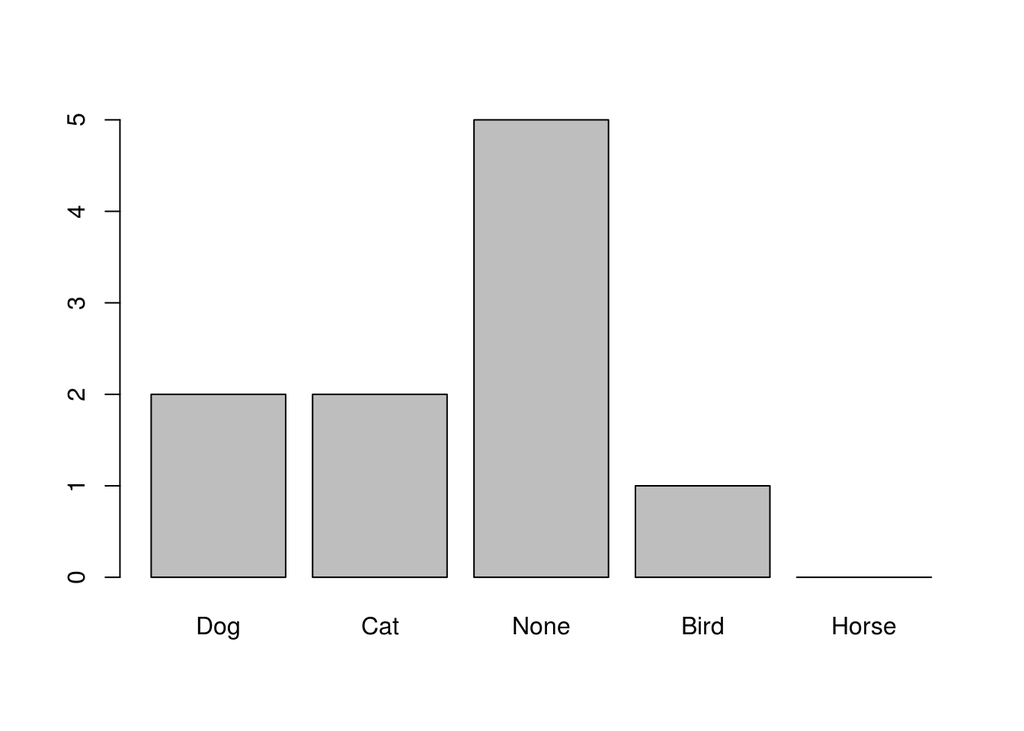

```r
barplot(table(patients$Pet))
```

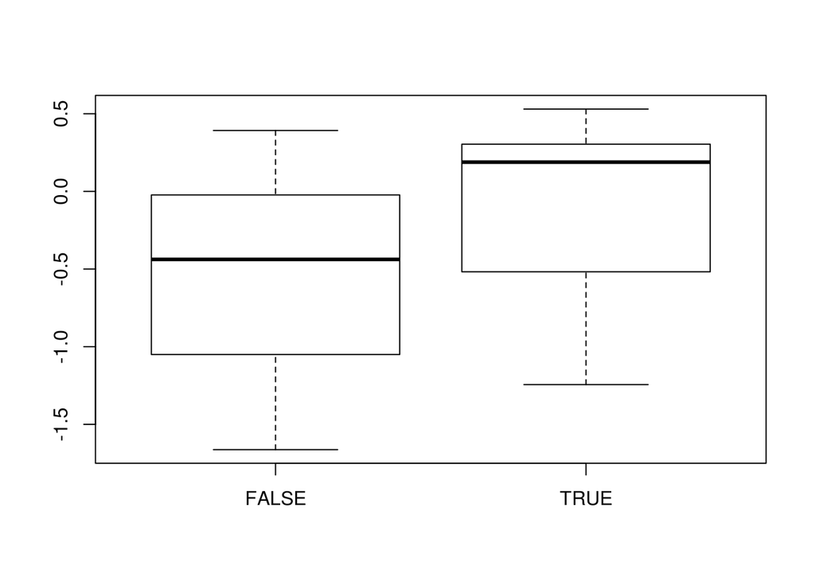

```r
boxplot(patients$Count ~ patients$Died)
```

*Lots* of customisations are possible to enhance the appaerance of our plots; colour, labels, axes, legends

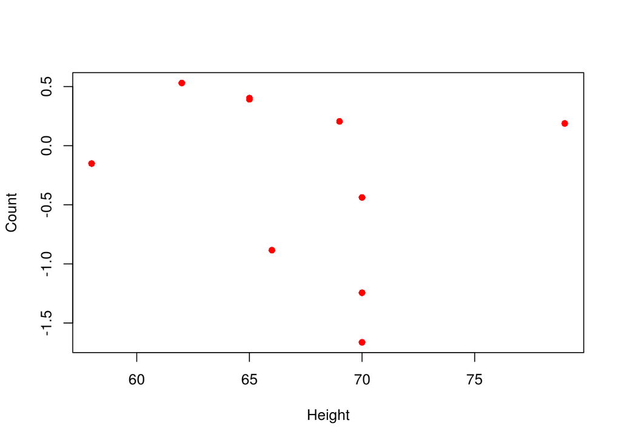

```r
plot(patients$Height,patients$Count,pch=16,
     col="red",xlab="Height",
     ylab="Count")
```

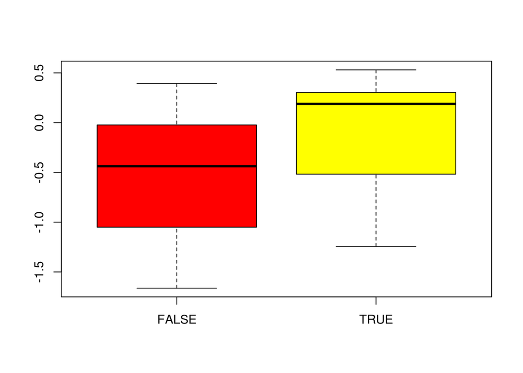

```r
boxplot(patients$Count ~ patients$Died,col=c("red","yellow"))
```

Plots can be exported by the *Plots* tab in RStudio, or by calling the `pdf` or `png` functions which will write the plot to a file

```r
png("myLittlePlot.png")
barplot(table(patients$Pet))
dev.off()
```